# MHAD Data Challenge

## Introduction

Hcange Nifancial is a regional bank based in Washington, DC. The leadership in Hcange Nifancial wants to explore entering a new market, home lending in the surrounding states such as MD, VA, WV, DL.

In this study I have analyzed the MHAD (Home Mortgage Disclosure Act) data set, published by the federal government every year. The study tries to answer questions about the regional home loans market.

## Data Munging

In this section I get the data loaded from the csv files and merge the home loans application data with the institutional loan data based on 'Respondent_Name'. I also create an additional column 'Loan_Groups' to categorize loans based on 'Loan_Amount_000'.

```python
%matplotlib inline
import unicodecsv as uc
import numpy as np
import pandas as pd
import seaborn as sns
import matplotlib.pyplot as plt
import warnings
warnings.filterwarnings('ignore')

# Data set csv files
loan_file ='2012_to_2014_loans_data.csv'
inst_file ='2012_to_2014_institutions_data.csv'

# Load data
loan_data = pd.read_csv(loan_file)
inst_data = pd.read_csv(inst_file)

# Merge the data sets
merged_data = pd.merge(loan_data, inst_data,
                           left_on=['As_of_Year','Agency_Code','Respondent_ID'],
                        right_on=['As_of_Year','Agency_Code','Respondent_ID'],
                        how='left')
```

```python
merged_data.info();
```

```
<class 'pandas.core.frame.DataFrame'>
Int64Index: 1321158 entries, 0 to 1321157
Data columns (total 33 columns):
Agency_Code                       1321158 non-null int64
Applicant_Income_000              1321158 non-null object
As_of_Year                        1321158 non-null int64
Census_Tract_Number               1321158 non-null object
County_Code                       1321158 non-null object
FFIEC_Median_Family_Income        1321158 non-null object
Loan_Amount_000                   1321158 non-null int64
MSA_MD                            1321158 non-null object
Number_of_Owner_Occupied_Units    1321158 non-null object
Respondent_ID                     1321158 non-null object
Sequence_Number                   1321158 non-null int64
State_Code                        1321158 non-null int64
Tract_to_MSA_MD_Income_Pct        1320258 non-null object
MSA_MD_Description                1225941 non-null object
Loan_Purpose_Description          1321158 non-null object
Agency_Code_Description           1321158 non-null object
Lien_Status_Description           1321158 non-null object
Loan_Type_Description             1321158 non-null object
State                             1321158 non-null object
County_Name                       1320321 non-null object
Conforming_Limit_000              1320321 non-null float64
Conventional_Status               1321158 non-null object
Conforming_Status                 1321158 non-null object
Conventional_Conforming_Flag      1321158 non-null object
Respondent_Name_TS                1222854 non-null object
Respondent_City_TS                1222854 non-null object
Respondent_State_TS               1222854 non-null object
Respondent_ZIP_Code               1222854 non-null object
Parent_Name_TS                    595643 non-null object
Parent_City_TS                    595643 non-null object
Parent_State_TS                   595785 non-null object
Parent_ZIP_Code                   596208 non-null object
Assets_000_Panel                  1222854 non-null float64
dtypes: float64(2), int64(5), object(26)
memory usage: 342.7+ MB
```

```python
# Take a look at a slice of data
merged_data.head(10)
```

|  | Agency_Code | Applicant_Income_000 | As_of_Year | Census_Tract_Number | County_Code | FFIEC_Median_Family_Income | Loan_Amount_000 | MSA_MD | Number_of_Owner_Occupied_Units | Respondent_ID | ... | Conventional_Conforming_Flag | Respondent_Name_TS | Respondent_City_TS | Respondent_State_TS | Respondent_ZIP_Code | Parent_Name_TS | Parent_City_TS | Parent_State_TS | Parent_ZIP_Code | Assets_000_Panel |
| --- | --- | --- | --- | --- | --- | --- | --- | --- | --- | --- | --- | --- | --- | --- | --- | --- | --- | --- | --- | --- | --- |
| 0 | 3 | 0084 | 2012 | 0207.00 | 079 | 00054900 | 94 | 16620 | 00001545 | 0000000384 | ... | Y | THE OHIO VALLEY BANK COMPANY | GALLIPOLIS | OH | 45631 | OHIO VALLEY BANC CORP | GALLIPOLIS | OH | 45631 | 793399.0 |
| 1 | 3 | 0084 | 2012 | 9556.00 | 043 | 00054900 | 133 | 16620 | 00001548 | 0000000384 | ... | Y | THE OHIO VALLEY BANK COMPANY | GALLIPOLIS | OH | 45631 | OHIO VALLEY BANC CORP | GALLIPOLIS | OH | 45631 | 793399.0 |
| 2 | 3 | 0053 | 2012 | 9556.00 | 043 | 00054900 | 70 | 16620 | 00001548 | 0000000384 | ... | Y | THE OHIO VALLEY BANK COMPANY | GALLIPOLIS | OH | 45631 | OHIO VALLEY BANC CORP | GALLIPOLIS | OH | 45631 | 793399.0 |
| 3 | 3 | 0085 | 2012 | 0206.01 | 079 | 00054900 | 102 | 16620 | 00001935 | 0000000384 | ... | Y | THE OHIO VALLEY BANK COMPANY | GALLIPOLIS | OH | 45631 | OHIO VALLEY BANC CORP | GALLIPOLIS | OH | 45631 | 793399.0 |
| 4 | 3 | 0038 | 2012 | 0107.01 | 039 | 00054900 | 112 | 16620 | 00001492 | 0000000384 | ... | Y | THE OHIO VALLEY BANK COMPANY | GALLIPOLIS | OH | 45631 | OHIO VALLEY BANC CORP | GALLIPOLIS | OH | 45631 | 793399.0 |
| 5 | 3 | 0113 | 2012 | 0206.05 | 079 | 00054900 | 133 | 16620 | 00002493 | 0000000384 | ... | Y | THE OHIO VALLEY BANK COMPANY | GALLIPOLIS | OH | 45631 | OHIO VALLEY BANC CORP | GALLIPOLIS | OH | 45631 | 793399.0 |
| 6 | 3 | 0091 | 2012 | 9555.00 | 043 | 00054900 | 192 | 16620 | 00001173 | 0000000384 | ... | Y | THE OHIO VALLEY BANK COMPANY | GALLIPOLIS | OH | 45631 | OHIO VALLEY BANC CORP | GALLIPOLIS | OH | 45631 | 793399.0 |
| 7 | 3 | 0025 | 2012 | 0121.00 | 039 | 00054900 | 36 | 16620 | 00001361 | 0000000384 | ... | Y | THE OHIO VALLEY BANK COMPANY | GALLIPOLIS | OH | 45631 | OHIO VALLEY BANC CORP | GALLIPOLIS | OH | 45631 | 793399.0 |
| 8 | 3 | 0111 | 2012 | 0019.02 | 039 | 00054900 | 191 | 16620 | 00001552 | 0000000384 | ... | Y | THE OHIO VALLEY BANK COMPANY | GALLIPOLIS | OH | 45631 | OHIO VALLEY BANC CORP | GALLIPOLIS | OH | 45631 | 793399.0 |
| 9 | 3 | 0070 | 2012 | 0206.05 | 079 | 00054900 | 110 | 16620 | 00002493 | 0000000384 | ... | Y | THE OHIO VALLEY BANK COMPANY | GALLIPOLIS | OH | 45631 | OHIO VALLEY BANC CORP | GALLIPOLIS | OH | 45631 | 793399.0 |

10 rows × 33 columns

The info() function shows that most of the variables are of type object. There are 1321158 records and not all columns have values in them. MSA_MD_Description, County_Name, Conforming_Limit_000, Respondent_Name_TS, Respondent_City_TS, Respondent_State_TS, Respondent_ZIP_Code, Assets_000_Panel have fewer records. Where as Parent_Name_TS, Parent_City_TS, Parent_State_TS, Parent_ZIP_Code are very sparsly populated.

Lets try to plot the distribution of data for Loan_Amount_000 and to create groups of reasonable size.

```
(0, 5000)
```

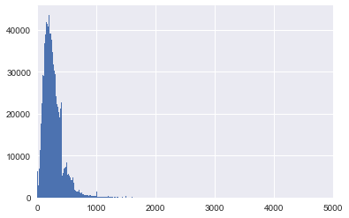

```python
import seaborn as sns
import matplotlib.pyplot as plt

# Checking the distribution of loan amount column
loan_data['Loan_Amount_000'].hist(bins=10000)
plt.xlim(0, 5000)
```

It can be seen that the distribution is right skewed; although this graph consits of loan data ranging between 0 and $ 5 million.

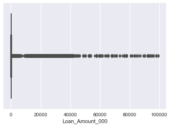

```python
bp=sns.boxplot(x=merged_data['Loan_Amount_000'])
```

```python
merged_data['Loan_Amount_000'].describe()
```

```
count    1.321158e+06
mean     2.902331e+02
std      9.657792e+02
min      1.000000e+00
25%      1.530000e+02
50%      2.350000e+02
75%      3.470000e+02
max      9.962500e+04
Name: Loan_Amount_000, dtype: float64
```

The box plot shows that although there are large number of loans in 0 to around 1 million dollars range. There are quite a few outliers with loan data ranging to an upper limit of 100 million dollars. Based on the above observations, I have created six groups of loan amounts as below (in $ '000 ) : 0-100 100-200 200-400 400-800 800-1000 1000 and above

```python
# Function to categorize loans based on loan amounts
def mhad_loan_groups(ln_amt):
    """
    Create 6 groups of Loan_Amount_000
    """
    if ln_amt < 100:
        return '0-100'
    elif ln_amt < 200:
        return '100-200'
    elif ln_amt < 400:
        return '200-400'
    elif ln_amt < 800:
        return '400-800'
    elif ln_amt < 1000:
        return '800-1000'
    else:
        return '1000-'

# Add the new bucket
merged_data['Loan_Group'] = merged_data.Loan_Amount_000.apply(mhad_loan_groups)
```

```python
def mhad_init(loan_file, inst_file):
    """
    Reads the data files and mergees the loan data with instituional data; so
    that each loan application is assigned a "Respondent_Name" from institutional
    data. And returns an object containing the expanded MHAD df
    """
    loan_data = pd.read_csv(loan_file)
    inst_data = pd.read_csv(inst_file)
    merged_data = pd.merge(loan_data, inst_data,
                           left_on=['As_of_Year','Agency_Code','Respondent_ID'],
                        right_on=['As_of_Year','Agency_Code','Respondent_ID'],
                        how='left')

    # Add the new bucket
    merged_data['Loan_Group'] = merged_data.Loan_Amount_000.apply(mhad_loan_groups)
    return merged_data

def mhad_to_json(data, states=None, conventional_conforming=None):
    """
    Exports the merged data set to disk, for states filtered by product segment
    The file is created by the name mhad_data.json in the same directory
    """
    if not states:
        states = data['State'].unique()

    if not conventional_conforming:
        conventional_conforming = ['Y', 'N']

    json_data=data[data.State.isin(states) &
    data.Conventional_Conforming_Flag.isin(conventional_conforming)]

    json_data.to_json('./mhad_data.json',orient='index')
    return
```

## Quality Check

In this section I perform quality assessment on Loan_Amount_000, Respondent_Name_TS, Application_Income_000 and As_of_Year. Checking for the NULLs across the data set colums by looking for percentage of null values for each column:

```python
null_pct = (merged_data.isnull().sum()*100)/len(merged_data)
null_pct.sort_values(ascending=False)
```

```
Parent_City_TS                    54.915082
Parent_Name_TS                    54.915082
Parent_State_TS                   54.904334
Parent_ZIP_Code                   54.872317
Assets_000_Panel                   7.440745
Respondent_ZIP_Code                7.440745
Respondent_State_TS                7.440745
Respondent_City_TS                 7.440745
Respondent_Name_TS                 7.440745
MSA_MD_Description                 7.207087
Tract_to_MSA_MD_Income_Pct         0.068122
Conforming_Limit_000               0.063354
County_Name                        0.063354
Loan_Group                         0.000000
MSA_MD                             0.000000
Loan_Amount_000                    0.000000
As_of_Year                         0.000000
FFIEC_Median_Family_Income         0.000000
County_Code                        0.000000
Census_Tract_Number                0.000000
Respondent_ID                      0.000000
Applicant_Income_000               0.000000
Number_of_Owner_Occupied_Units     0.000000
Lien_Status_Description            0.000000
Sequence_Number                    0.000000
State_Code                         0.000000
Loan_Purpose_Description           0.000000
Agency_Code_Description            0.000000
Loan_Type_Description              0.000000
State                              0.000000
Conventional_Status                0.000000
Conforming_Status                  0.000000
Conventional_Conforming_Flag       0.000000
Agency_Code                        0.000000
dtype: float64
```

As observed earlier, the Parent_xxx columns from institutional dataset contain lots of null values. Respondent_xxx columns also contain more tha 7% of null values. This makes me belive that institutional data up keep is not a major concern for the MHAD act. Although ideally there should not be any missing values from the respondents.

### Loan_Amount_000

The first column of interest, Loan_Amount_000 has 0 null values as shown above. Let's check if there are any NaNs.

```python
nan_cnt=0
nan_l = []
merged_data.Loan_Amount_000.isnull().sum() #There are no Null values
for i in merged_data['Loan_Amount_000']:
    if np.isnan(i) == True:
        cnt+=1
        nan_l.append(i)

print("There are ", nan_cnt, " NaN values for Loan_Amount_000")
nan_l
```

```
There are  0  NaN values for Loan_Amount_000
```

```
[]
```

As we had observed before, the distribution for Loan_Amount_000 seems to be highly right skewed and there seem to be large number of outliers in the dataset. But, I think we should not be removing any of the seemingly outlier values from the data. The box plot for loan amounts shows us that between the average and maximum values, there are multiple loan amounts that exist and show that the maximum amount might not be due to a data error. Hence I don't think we need to do any processing for outliers with the Loan_Amount_000 field.

### Respondent_Name_TS

This field comes from the institutional data set. As with Loan_Amount_000, I will check for any null values.

There are other fields for respondents which include, Respondent_ID and Agency_Code. The combination of Respondent_ID and Agency_Code is unique for the reporting insitution for a given year. We can check if the combination of Respondent_ID, Agency_Code did uniqly match with the Respondent_Name_TS.

```python
inst_data.Respondent_Name_TS.isnull().sum()
```

```
0
```

```python
print(inst_data[['Agency_Code','Respondent_ID','As_of_Year','Respondent_Name_TS']].
      drop_duplicates().
      sort_values(by=['Agency_Code','Respondent_ID','As_of_Year','Respondent_Name_TS'], ascending=[1,1,1,1]))
```

```
       Agency_Code Respondent_ID  As_of_Year              Respondent_Name_TS
14592            1    0000000046        2014  FIRST NATIONAL BANK OF MCCONNE
0                1    0000000047        2012         FIRST FINANCIAL BANK NA
7401             1    0000000047        2013         FIRST FINANCIAL BANK NA
14593            1    0000000047        2014         FIRST FINANCIAL BANK NA
1                1    0000000056        2012      FIRST FINANCIAL BANK, N.A.
7402             1    0000000056        2013      FIRST FINANCIAL BANK, N.A.
14594            1    0000000056        2014      FIRST FINANCIAL BANK, N.A.
2                1    0000000086        2012  FIRST NATIONAL BANK OF GERMANT
7403             1    0000000086        2013  FIRST NATIONAL BANK OF GERMANT
14595            1    0000000086        2014  FIRST NATIONAL BANK OF GERMANT
3                1    0000000182        2012  EXCHANGE NATIONAL BANK & TRUST
7404             1    0000000182        2013  EXCHANGE NATIONAL BANK & TRUST
14596            1    0000000182        2014  EXCHANGE NATIONAL BANK & TRUST
4                1    0000000324        2012   FIRST NATIONAL BANK AND TRUST
```

[output cut: 49 more lines]

Looking at the outputs above, there are no null values in the first output. In the second output, the first few records about 'FIRST FINANCIAL BANK NA' and 'FIRST FINANCIAL BANK, N.A.' the two institutions seems to be very similar by name although the Respondent_ID are different for all the 3 years. Taking a closer look at the two below, they seem to be different branches, may be of the same parent. But this can't be confirmed because for one of them, the parent information is NAN.

```python
inst_data [(inst_data['Respondent_ID']=='0000000047') & (inst_data['Agency_Code']==1)]
```

|  | As_of_Year | Respondent_ID | Agency_Code | Respondent_Name_TS | Respondent_City_TS | Respondent_State_TS | Respondent_ZIP_Code | Parent_Name_TS | Parent_City_TS | Parent_State_TS | Parent_ZIP_Code | Assets_000_Panel |
| --- | --- | --- | --- | --- | --- | --- | --- | --- | --- | --- | --- | --- |
| 0 | 2012 | 0000000047 | 1 | FIRST FINANCIAL BANK NA | TERRE HAUTE | IN | 47802 | FIRST FINANCIAL CORPORATION | TERRE HAUTE | IN | 47807 | 2854392 |
| 7401 | 2013 | 0000000047 | 1 | FIRST FINANCIAL BANK NA | TERRE HAUTE | IN | 47802 | FIRST FINANCIAL CORPORATION | TERRE HAUTE | IN | 47807 | 2793023 |
| 14593 | 2014 | 0000000047 | 1 | FIRST FINANCIAL BANK NA | TERRE HAUTE | IN | 47802 | FIRST FINANCIAL CORPORATION | TERRE HAUTE | IN | 47807 | 2934275 |

```python
inst_data [(inst_data['Respondent_ID']=='0000000056') & (inst_data['Agency_Code']==1)]
```

|  | As_of_Year | Respondent_ID | Agency_Code | Respondent_Name_TS | Respondent_City_TS | Respondent_State_TS | Respondent_ZIP_Code | Parent_Name_TS | Parent_City_TS | Parent_State_TS | Parent_ZIP_Code | Assets_000_Panel |
| --- | --- | --- | --- | --- | --- | --- | --- | --- | --- | --- | --- | --- |
| 1 | 2012 | 0000000056 | 1 | FIRST FINANCIAL BANK, N.A. | CINCINNATI | OH | 45202 | NaN | NaN | NaN | NaN | 6663427 |
| 7402 | 2013 | 0000000056 | 1 | FIRST FINANCIAL BANK, N.A. | CINCINNATI | OH | 45202 | NaN | NaN | NaN | NaN | 6487854 |
| 14594 | 2014 | 0000000056 | 1 | FIRST FINANCIAL BANK, N.A. | CINCINNATI | OH | 45202 | NaN | NaN | NaN | NaN | 6410604 |

In the ideal scenario, the institution data should be complete to understand the respondents thoroughly. There is also a chance of having the same combination of Agency_Code and Respondent_ID correspond to different Respondent_Name_TS values, although with very slight variations. I would not recommend basing the analysis on Respondent_Name_TS variable for these reasons due to inconsistencies.

### Applicant_Income_000

I have considered this variable for quality check since it is an important determinant in understanding the ability of people to service the loans and is an indicator of the health of the market. The data set has it as type object, although it'll be good to convert it to a number for numerical analysis. Running the describe() function against this variable shows it as being a catagorical with many NA values.

```python
merged_data['Applicant_Income_000'].describe()
```

```
count     1321158
unique       2316
top          NA
freq       117853
Name: Applicant_Income_000, dtype: object
```

```python
app_inc=[]
for i in merged_data['Applicant_Income_000']:
    if str(i).isdigit()==True:
        app_inc.append(int(i))
app_inc=pd.Series(app_inc)
app_inc.describe()
```

```
count    1.203305e+06
mean     1.180193e+02
std      1.226957e+02
min      0.000000e+00
25%      6.000000e+01
50%      9.400000e+01
75%      1.420000e+02
max      9.999000e+03
dtype: float64
```

```python
na_cnt=0
ai_arr=[]
md_app_inc=app_inc.median()
for i in enumerate(merged_data['Applicant_Income_000']):
    if i[1] == 'NA ' or i[1]=='NA  ':
        na_cnt += 1
        j=md_app_inc # Fix the missing with median/mean
    else:
        j = int(i[1])
    ai_arr.append(j)

merged_data['Applicant_Income_000_int']=ai_arr
merged_data['Applicant_Income_000_int'].describe()
```

```
count    1.321158e+06
mean     1.158767e+02
std      1.172954e+02
min      0.000000e+00
25%      6.300000e+01
50%      9.400000e+01
75%      1.360000e+02
max      9.999000e+03
Name: Applicant_Income_000_int, dtype: float64
```

### As_of_Year

Since, in the description of this variable it was mentioned that every year people fill might fill it in a different way. Hence I chose this column to see if that is the case and found this to be a clean variable.

```python
merged_data['As_of_Year'].describe()
```

```
count    1.321158e+06
mean     2.012797e+03
std      7.752387e-01
min      2.012000e+03
25%      2.012000e+03
50%      2.013000e+03
75%      2.013000e+03
max      2.014000e+03
Name: As_of_Year, dtype: float64
```

```python
merged_data['As_of_Year'].value_counts(normalize=True,sort=True, ascending=False, bins=None, dropna=True)
```

```
2012    0.422272
2013    0.357987
2014    0.219741
Name: As_of_Year, dtype: float64
```

#### Data Quality Summary

As a set of rules for monitoring data quality, I would recommend the following set of rules to be kept in mind: A standard set of checks must be performed on every critical field/variable, which include:

```
* Check for Nulls and drop them
* Check for NaN values and see if they can be replaced with a reasonable alternative
* Have a defined datatype for each field, and if not then try to convert them to assist effective analysis
* Look for abonormal values in a set of data elements which deviate from the type of the data field
* Look for outliers and if they can and should be removed or remain a part of the data analysis
* Plot the fields to understand distribution among themselves in a univariate chart or in relation with others in a bivariate chart
```

## Visualizations

I recorded a string of multiple visualizations to understand the relationship among variables and help drive a conclusion. I will summarize my findings at the end of this section and explain the recommended actions. Based on my current understanding of data seen so far, the market appears to be highly saturated with a large number of competitors.

Although housing sector has seen recovery post the financial crash of 2007-08 and this region being among the wealthiest of the nation, one might feel attracted towards the market. If the people of the region have a good income and the region is home to some of the most expensive properties, then the market is worth exploring. Here I also assume that Hcange Nifancial is in a sound health to invest (time, finances, people, leadership will and investor confidence) resources in entering into a new market, since this information is not given. I would also assume that the bank would be holding the assets rather than selling them as mortgage backed securities.

### Volume

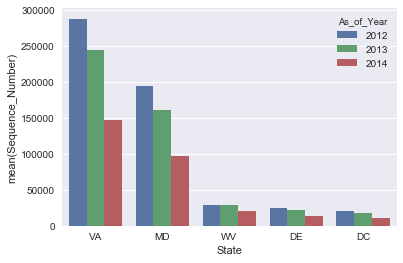

```python
st_vol=merged_data.groupby(['State','As_of_Year'])['Sequence_Number'].count().to_frame().reset_index()
st_vol_sort=st_vol.sort_values(by='Sequence_Number',ascending=False)

sns_plt_1=sns.barplot(x='State', hue='As_of_Year', y='Sequence_Number', data=st_vol_sort)
```

### Loan Amounts

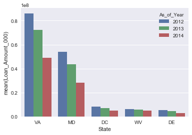

```python
st_amt=merged_data.groupby(['State','As_of_Year'])['Loan_Amount_000'].sum().to_frame().reset_index()
st_amt_sort=st_amt.sort_values(by='Loan_Amount_000',ascending=False)

sns_plt_2=sns.barplot(x='State', hue='As_of_Year', y='Loan_Amount_000', data=st_amt_sort)
```

### Loan Purpose

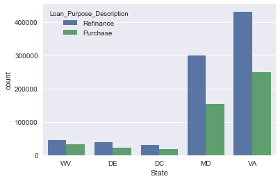

```python
sns_plt_loan_t=sns.countplot(x='State',hue='Loan_Purpose_Description', data=merged_data)
```

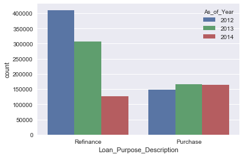

```python
sns_plt_loan_p=sns.countplot(x='Loan_Purpose_Description',hue='As_of_Year', data=merged_data)
```

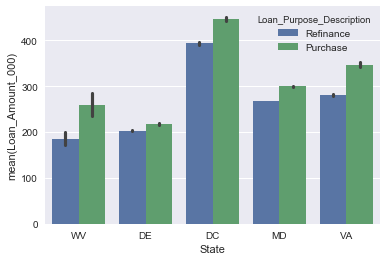

```python
sns_plt_x=sns.barplot(x='State', hue='Loan_Purpose_Description', y='Loan_Amount_000', data=merged_data)
```

### Loan Type

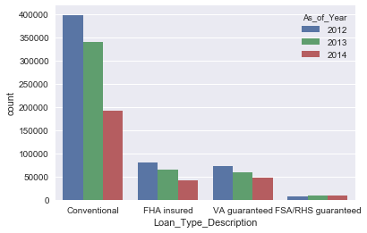

```python
sns_plt_loan_t=sns.countplot(x='Loan_Type_Description',hue='As_of_Year', data=merged_data)
```

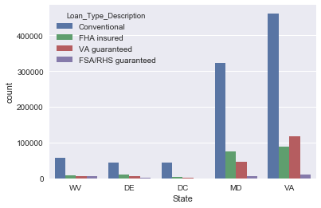

```python
sns_plt_loan_t=sns.countplot(x='State',hue='Loan_Type_Description', data=merged_data)
```

### Applicant Income

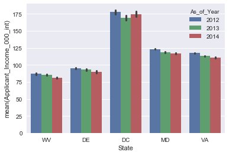

```python
sns_plt_appl_inc=sns.barplot(y='Applicant_Income_000_int',x='State', hue='As_of_Year', data=merged_data)
```

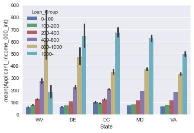

```python
sns_plt_appl_inc=sns.barplot(y='Applicant_Income_000_int',x='State', hue='Loan_Group', data=merged_data)
```

### Loan_Group vs State

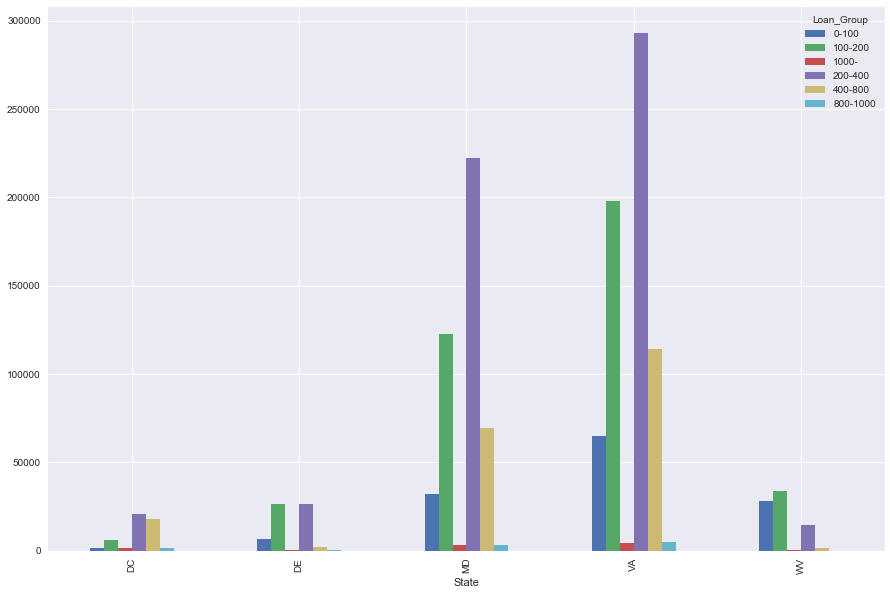

```python
crosstab1=pd.crosstab(index=merged_data.State,
                      columns=[merged_data.Loan_Group])
crosstab1.plot(kind="bar",
                 figsize=(15, 10))
```

### Loan Group by Year

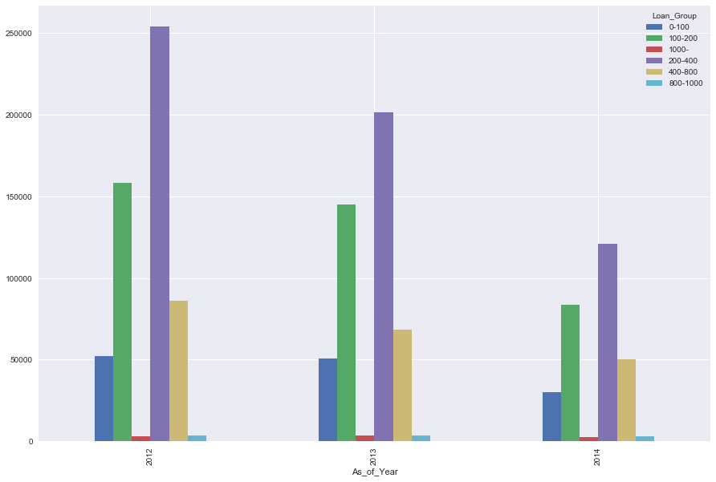

```python
crosstab2=pd.crosstab(index=merged_data.As_of_Year,
                      columns=[merged_data.Loan_Group])
crosstab2.plot(kind="bar",
                 figsize=(15, 10))
```

### Product by State

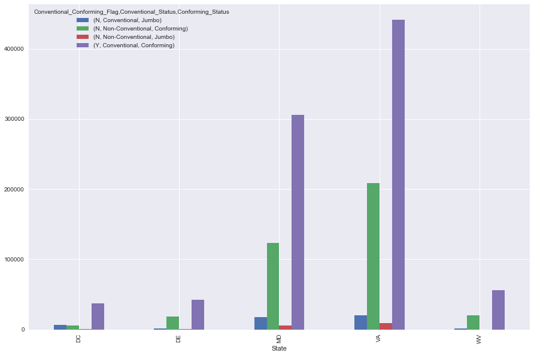

```python
crosstab3=pd.crosstab(index=merged_data.State,
                      columns=[merged_data.Conventional_Conforming_Flag,
                               merged_data.Conventional_Status,merged_data.Conforming_Status])
crosstab3.plot(kind="bar",
                 figsize=(15,10))
```

### Loan Purpose by State & Year

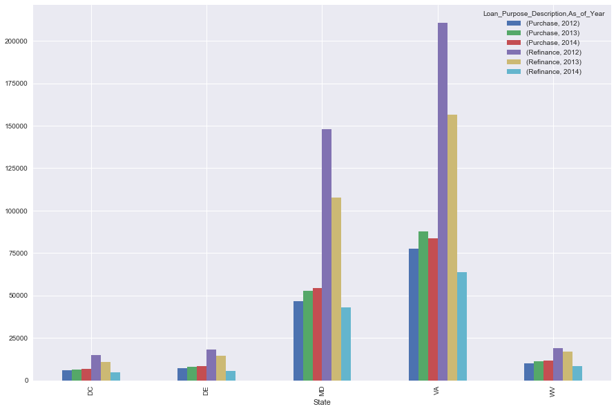

```python
crosstab4=pd.crosstab(index=merged_data.State,
                      columns=[merged_data.Loan_Purpose_Description, merged_data.As_of_Year])
crosstab4.plot(kind="bar",
                 figsize=(15,10))
```

### Summary

When we look at the loan type, between purchase and refinance; the refinance market seems much bigger, but has seen a big decline. The purchase market has remained steady on the other hand. It seems that the refinance market has been overstaturated with assets changing hands to squeeze out the last % basis points of savings due to heavy competition. It also seems that lenders are comfortable refinancing an already financed loan as the initial cost incurring due diligence would have been completed and refinance wouln't require as much due diligence. It would be really interesting to see the markets just for the 1st time bought inventory as well as the market of 1st time home buyers. Between refinance and purchase, the asset value is only slightly less for refinance than for purchase. I think with property prices holding and some of the loan paid off over some time, refinancing would require a lesser loan amount.

Applicant incomes show slight decline over the three years but relatively lesser decline than that of the loan amounts. The applicant income is proportional to the loan group for which they apply. The 200k-400k USD group is most popular in terms of number of loans, but has seen a decline over last 3 years. Virginia seems to be the biggest market in terms of volume followed by Maryland.

Based on the observations above I recommend that Hcange Nifancial should not be considering an entry in the home loan market till the trends reverse. If they still wanted to expand their product offering keeping in mind a longer term goal, they should consider an acquisition of an existing lender of suitable size in a specific part of the region. But, determining an acquisition target will be another exhaustive exercise. An acquisition can give them a quick entry in the market where they can test the waters before deciding to expand further or exit.

## One Last Thing

In the last step, I have tried to make this study/notebook interactive using iPython Widgets and help dig deeper in the analysis from the last section. I look for competitive information with respect to each year and the state and draw a bar chart to understand the regional markets better. This section can be further expanded to add more types of charts and provide the users more tools to select from.

```
Displaying the competition graph for year:  2013 , in state:  VA
```

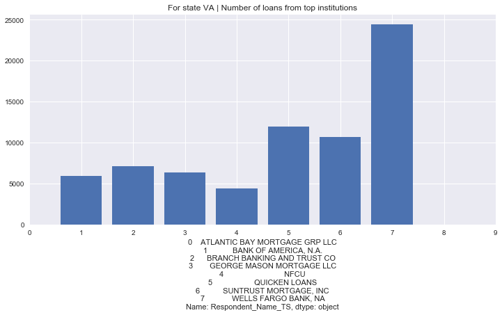

```python
import ipywidgets as wg
from IPython.display import display
wg.Widget.widget_types
from IPython.display import clear_output
from matplotlib import rcParams

# Dropdown to select year
year=wg.Dropdown(options={'2012': 2012, '2013': 2013, '2014': 2014},
                description='Year')
# Dropdown to select State
state=wg.Dropdown(options={'DC': 'DC', 'DE': 'DE', 'MD': 'MD', 'VA': 'VA', 'WV': 'WV'},
                description='State')
# Slider to select number of top competitors to be viewed
num_compt=wg.SelectionSlider(
    description='Number of competitors',
    options=[5, 6, 7, 8, 9, 10],
    disabled=False,
    continuous_update=False,
    orientation='horizontal',
    readout=True,)
display(year)
display(state)
display(num_compt)

# Click this button to create the graph
button = wg.Button(description='Plot Competition')
display(button)

# This function will be called when the button on interactive display is clicked
def on_button_clicked(b):
    clear_output()
    print ("Displaying the competition graph for year: ", int(year.value), ", in state: ", str(state.value))

    resp_cnt = pd.DataFrame({'Mortgage_Count': merged_data.groupby(['As_of_Year', 'Respondent_Name_TS',
                                                                  'State']).size()}).reset_index()
    resp_state = resp_cnt.loc[resp_cnt['State'] == str(state.value)]
    resp_state = resp_state.sort_values(['As_of_Year', 'Mortgage_Count'], ascending=[False, False])

    # Get the count of competitors from the slider selection
    num_compt_v=int(num_compt.value)
    # get the top selected lenders for the most recent year
    top_resp = resp_state['Respondent_Name_TS'][:num_compt_v]

    # get the data for top institutions
    top_inst_data = resp_state[resp_state['Respondent_Name_TS'].isin(top_resp)].reset_index()

    # rearrange the data using pivot for the bar chart
    top_inst_g = top_inst_data.pivot(index='Respondent_Name_TS', columns='As_of_Year',
                                               values='Mortgage_Count').reset_index()
    # size the figure
    rcParams['figure.figsize'] = 12, 7

    # data for selected year
    data1 = np.array(top_inst_g[int(year.value)])

    fig, ax = plt.subplots()
    bar_locations = np.arange(num_compt_v)
    ax.bar(bar_locations, data1, label=str(year.value))
    plt.xlabel(top_inst_g['Respondent_Name_TS'])
    plt.title('For state %s | Number of loans from top institutions' % str(state.value))
    fig.subplots_adjust(bottom=0.28)
    plt.xticks(range(10), range(10))

button.on_click(on_button_clicked)
```